# HW4

Author

Jiaqi

GitHub repository: https://github.com/Julie0707/506_HW4

## Problem 1 - Tidyverse

1. Generate a table reporting the mean and median departure delay per airport. Generate a second table reporting the mean and median arrival delay per airport. Exclude any destination with under 10 flights. Do this exclusion through code, not manually.

```r
library(nycflights13)
library(tidyverse)
data("flights")
data("airports")

# the mean and median departure delay per airport
departure_delays <- flights %>%
  # Group data by departure airport: origin
  group_by(origin) %>%
  summarise(
    mean_delay = mean(dep_delay, na.rm = TRUE),
    median_delay = median(dep_delay, na.rm = TRUE),
    # Ensures the resulting tibble is ungrouped
    .groups = "drop"
  ) %>%
  # Order by mean delay in desc order
  arrange(-mean_delay) %>%
  # Join with the airports to get the airports' names
  left_join(airports, by = c("origin" = "faa")) %>%
  # Select the columns to display
  select(name, mean_delay, median_delay)

print(departure_delays)
```

```
# A tibble: 3 × 3
  name                mean_delay median_delay
  <chr>                    <dbl>        <dbl>
1 Newark Liberty Intl       15.1           -1
2 John F Kennedy Intl       12.1           -1
3 La Guardia                10.3           -3
```

```r
# the mean and median arrival delay per airport
arrival_delays <- flights %>%
  # Group data by destination airport
  group_by(dest) %>%
  # Summarise the mean and median arrival delays
  summarise(
    mean_delay = mean(arr_delay, na.rm = TRUE),
    median_delay = median(arr_delay, na.rm = TRUE),
    flight_count = n(),
    # Ensures the resulting tibble is ungrouped
    .groups = "drop"
  ) %>%
  # Filter out destinations with < 10 flights
  filter(flight_count >= 10) %>%
  # Order by mean delay in desc order
  arrange(-mean_delay) %>%
  # Get the airports' names
  left_join(airports, by = c("dest" = "faa")) %>%
  # Select the columns to display
  select(name, mean_delay, median_delay)

print(arrival_delays, n = nrow(arrival_delays))
```

```
# A tibble: 102 × 3
    name                                   mean_delay median_delay
    <chr>                                       <dbl>        <dbl>
  1 "Columbia Metropolitan"                   41.8            28
  2 "Tulsa Intl"                              33.7            14
  3 "Will Rogers World"                       30.6            16
  4 "Jackson Hole Airport"                    28.1            15
  5 "Mc Ghee Tyson"                           24.1             2
  6 "Dane Co Rgnl Truax Fld"                  20.2             1
  7 "Richmond Intl"                           20.1             1
  8 "Akron Canton Regional Airport"           19.7             3
  9 "Des Moines Intl"                         19.0             0
 10 "Gerald R Ford Intl"                      18.2             1
 11 "Birmingham Intl"                         16.9            -2
 12 "Theodore Francis Green State"            16.2             1
```

[output cut: 90 more lines]

2. How many flights did the aircraft model with the fastest average speed take? Produce a tibble with 1 row, and entires for the model, average speed (in MPH) and number of flights.

```r
data("planes")

# Calculate average speed, group by aircraft model
fastest_aircraft <- flights %>%
  # Filter out distance or air_time is NA
  filter(!is.na(distance), !is.na(air_time)) %>%

  # Calculate average speed
  mutate(speed_mph = distance / (air_time / 60)) %>%

  # Group by tailnum (representing aircraft model)
  group_by(tailnum) %>%

  # Summarize average speed and number of flights
  summarise(
    avg_speed = mean(speed_mph, na.rm = TRUE),
    num_flights = n()
  ) %>%

  # Arrange by average speed in desc order and take the first row
  arrange(desc(avg_speed)) %>%
  slice(1)

fastest_aircraft
```

```
# A tibble: 1 × 3
  tailnum avg_speed num_flights
  <chr>       <dbl>       <int>
1 N228UA       501.           1
```

## Problem 2 - get_temp()

```r
library(tidyverse)
get_temp <- function(month, year, data, celsius = FALSE, average_fn = mean) {
  result <- tryCatch({
    # Sanitize input
    if (is.numeric(month)) {
      if (month < 1 || month > 12) {
        stop("Month must be between 1 and 12")
      }
      month_num <- month
    } else if (is.character(month)) {
      month <- match(month, c(month.abb, month.name), nomatch = 0)

      if (month > 12){
        month <-  month - 12
      }
      if (month == 0) {
        stop("Invalid month name")
      }
    } else {
      stop("Month must be a number or a string")
    }
    month_num <- as.integer(month)

    year_num <- year
    if (!is.numeric(year_num) || (year_num > max(data$year))) {
      stop("Year must be an integer and be within range")
    }

    if (!is.data.frame(data)) {
      stop("Data must be a data frame")
    }

    if (!is.logical(celsius)) {
      stop("Celsius must be a logical value")
    }

    if (!is.function(average_fn)) {
      stop("average_fn must be a function")
    }
    # Convert temperature to Celsius
    if (celsius) {
      data <- data %>%
        mutate(temp = (temp - 32) * 5 / 9)
    }
    # Filter data by month and year, Calculate average temperature
    data_temp <- data %>%
      filter(month_numeric == month_num, year == year_num) %>%
      summarise(avg_temp = average_fn(temp))
      #pull(avg_temp)
      data_temp$avg_temp
  }, error = function(e) {
    message("Error: ", e$message)
    NA_real_
  })

  return(result)
}

# Load the Chicago NNMAPS data
nnmaps <- read.csv("/Users/jiaqizhu/Downloads/506/506_HW4/chicago-nmmaps.csv", header = TRUE)
test1 <- get_temp("Apr", 1999, data = nnmaps)
test2 <- get_temp("Apr", 1999, data = nnmaps, celsius = TRUE)
test3 <- get_temp(10, 1998, data = nnmaps, average_fn = median)
test4 <- get_temp(13, 1998, data = nnmaps)
```

```
Error: Month must be between 1 and 12
```

```r
test5 <- get_temp(2, 2005, data = nnmaps)
```

```
Error: Year must be an integer and be within range
```

```r
test6 <- get_temp("November", 1999, data =nnmaps, celsius = TRUE,
         average_fn = function(x) {
           x %>% sort -> x
           x[2:(length(x) - 1)] %>% mean %>% return
         })
print(test1)
```

```
[1] 49.8
```

```r
print(test2)
```

```
[1] 9.888889
```

```r
print(test3)
```

```
[1] 55
```

```r
print(test4)
```

```
[1] NA
```

```r
print(test5)
```

```
[1] NA
```

```r
print(test6)
```

```
[1] 7.301587
```

## Problem 3 - SAS

```sas
proc import datafile="/home/u63642979/hw4p3/recs2020_public_v5.csv" out=recs2020 dbms=csv replace;
  getnames=yes;
run;
```

The SAS results for Problem 3 in html

1. What state has the highest percentage of records? What percentage of all records correspond to Michigan?

```sas
proc freq data=recs2020 order=freq;
  tables state_name;
  weight nweight;
run;
```

California has the highest percentage of records; Michigan is 3.17%.

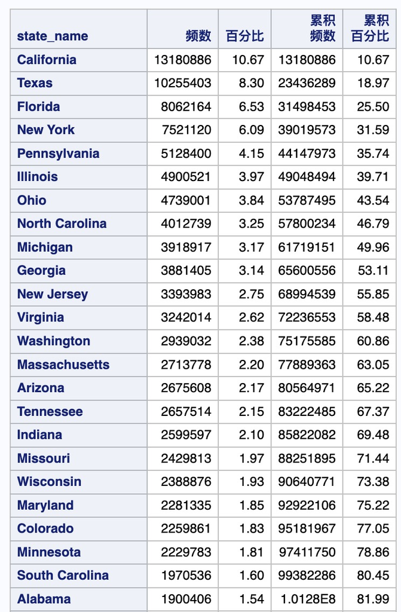

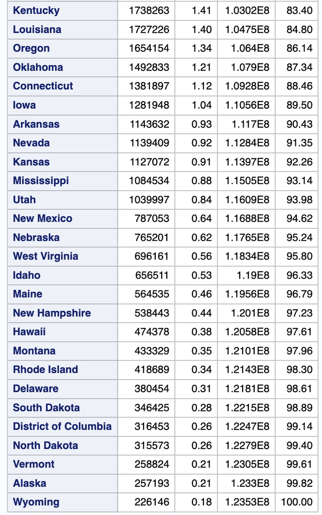

2. Generate a histogram of the total electricity cost in dollars, amongst those with a strictly positive cost.

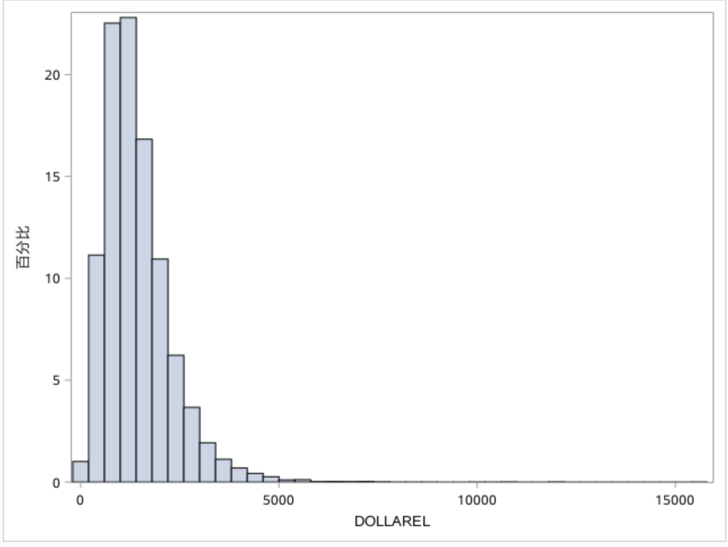

```sas
proc sgplot data=recs2020;
  where dollarel > 0;
  histogram dollarel;
run;
```

3. Generate a histogram of the log of the total electricity cost.

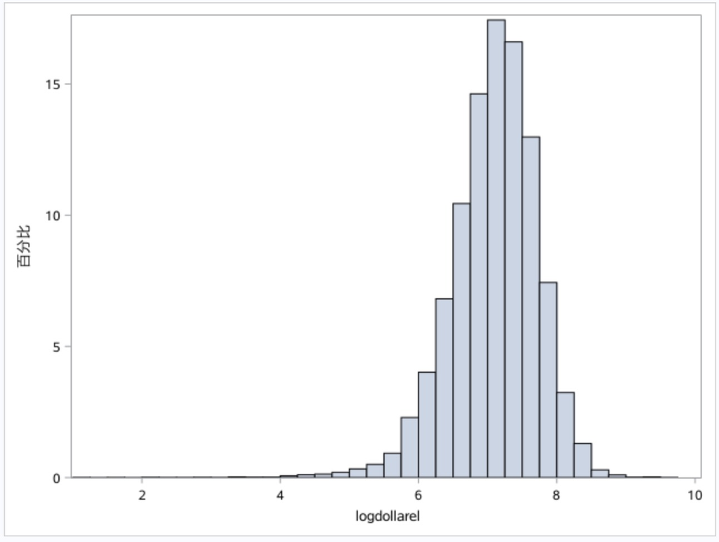

```sas
data recs2020_log;
  set recs2020;
  where dollarel > 0 ;
  logdollarel = log(dollarel);
run;

proc sgplot data=recs2020_log;
  histogram logdollarel;
run;
```

4. Fit a linear regression model predicting the log of the total electricity cost based upon the number of rooms in the house and whether or not the house has a garage.

```sas
proc reg data= recs2020_log;
    where prkgplc1 >= 0 ;
    weight nweight;
    model logdollarel = totrooms prkgplc1;
    output out=predicted_values pred=pred;
run;
```

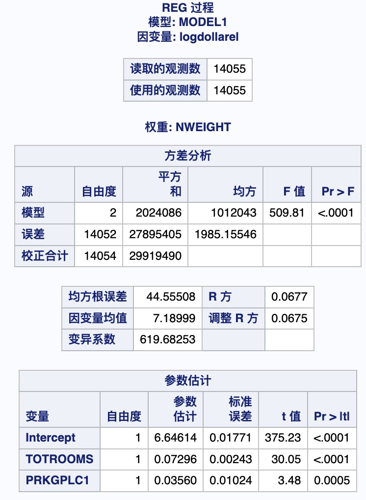

5. Use that model to generate predicted values and create a scatterplot of predicted total electricity cost vs actual total electricity cost (not on the log scale).

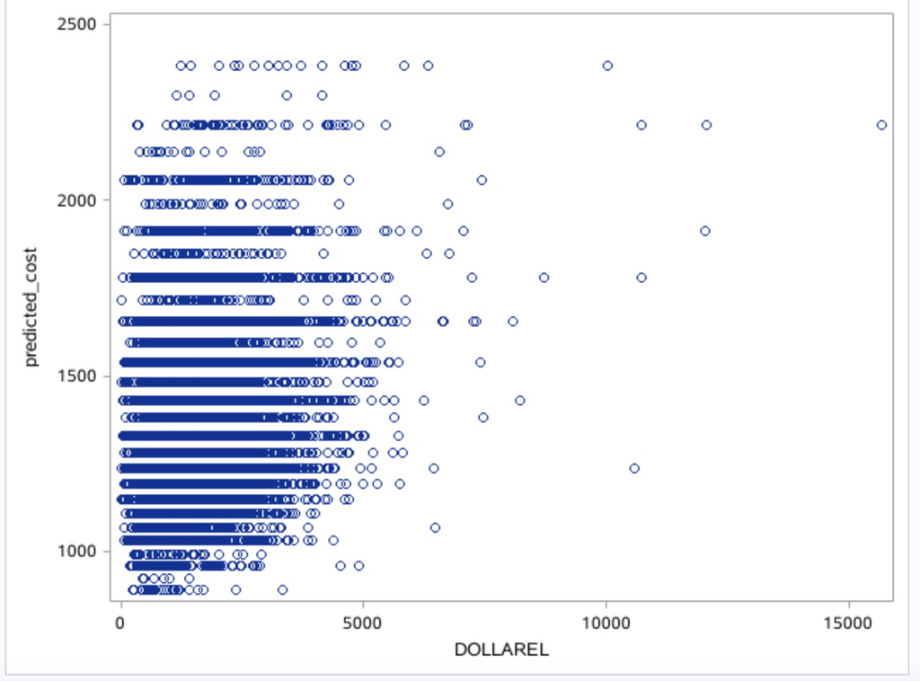

```sas
data predicted_values;
   set predicted_values;
   predicted_cost = exp(pred);
run;

proc sgplot data=predicted_values;
  scatter x=dollarel y=predicted_cost;
run;
```

## Problem 4 - Multiple tools

1. Take a look at the Codebook. For very minor extra credit, how was the Codebook generated?

It is generated with Stata.

2. Import the data into SAS and use proc sql to select only the variables you’ll need for your analysis

```sas
proc import datafile="/home/u63642979/hw4p3/public2022.csv" out=public2022 dbms=csv replace;
  getnames=yes;
run;

/*b*/
proc sql;
  create table subset_data as
  select public2022.CaseID, public2022.weight_pop, public2022.b3, public2022.nd2, public2022.b7_a, public2022.gh1, public2022.educ_4cat, public2022.ppethm
  from public2022;
quit;
```

3. Get the data out of SAS and into Stata

```sas
proc export data=subset_data outfile="/home/u63642979/hw4p3/subdataset.csv" dbms=csv replace;
run;
```

4. Demonstrate that you’ve successfully extracted the appropriate data by showing the number of observations and variables.

```stata
.
. cd "/Users/jiaqizhu/Downloads/506"
/Users/jiaqizhu/Downloads/506

.
end of do-file

. do "/var/folders/l1/y65z_mxj42s8n3793_nb4fv00000gn/T//SD42413.000000"

. log using hw4_p4.log, replace
(note: file /Users/jiaqizhu/Downloads/506/hw4_p4.log not found)
-------------------------------------------------------------------------------------------------------
      name:  <unnamed>
       log:  /Users/jiaqizhu/Downloads/506/hw4_p4.log
  log type:  text
 opened on:  23 Oct 2023, 02:15:08


. import delimited "subdataset.csv"
(8 vars, 11,667 obs)

.
. describe

Contains data
  obs:        11,667
 vars:             8
 size:     1,995,057
-------------------------------------------------------------------------------------------------------
              storage   display    value
variable name   type    format     label      variable label
-------------------------------------------------------------------------------------------------------
caseid          int     %8.0g                 CaseID
weight_pop      float   %9.0g
b3              str19   %19s                  B3
nd2             str15   %15s                  ND2
b7_a            str9    %9s                   B7_a
gh1             str57   %57s                  GH1
educ_4cat       str43   %43s
ppethm          str22   %22s
-------------------------------------------------------------------------------------------------------
Sorted by:
     Note: Dataset has changed since last saved.
```

5. The response variable is a Likert scale; convert it to a binary of worse off versus same/better.

```stata
. gen sameorbetter = 0

. replace sameorbetter = 1 if b3 == "Much better off" | b3 == "About the same" | b3 == "Somewhat better
>  off"
(7,371 real changes made)
```

6. Use the following code to tell Stata that the data is from a complex sample, Carry out a logisitic regression model accounting for the complex survey design. Be sure to treat variables you think should be categorical appropriately. From these results, provide an answer to the researchers question of interest.

```stata
. encode nd2, generate(nd2_num)

. encode b7_a, generate(b7_a_num)

. encode gh1, generate(gh1_num)

. encode educ_4cat, generate(educ_4cat_num)

. encode ppethm, generate(ppethm_num)

. svyset caseid [pw=weight_pop]

      pweight: weight_pop
          VCE: linearized
  Single unit: missing
     Strata 1: <one>
         SU 1: caseid
        FPC 1: <zero>


. svy: logistic sameorbetter i.nd2_num i.b7_a_num i.gh1_num i.educ_4cat_num i.ppethm_num
(running logistic on estimation sample)

Survey: Logistic regression

Number of strata   =         1                Number of obs     =       11,667
Number of PSUs     =    11,667                Population size   =  255,114,223
                                              Design df         =       11,666
                                              F(  17,  11650)   =        55.33
                                              Prob > F          =       0.0000

------------------------------------------------------------------------------------------------------
                                     |             Linearized
                        sameorbetter | Odds Ratio   Std. Err.      t    P>|t|     [95% Conf. Interval]
-------------------------------------+----------------------------------------------------------------
                             nd2_num |
                        Much higher  |   1.005597   .0852199     0.07   0.947     .8516883    1.187317
                         Much lower  |   1.266262   .1916566     1.56   0.119     .9411859    1.703615
                    Somewhat higher  |   1.069642   .0576705     1.25   0.212     .9623668    1.188876
                     Somewhat lower  |    1.29174   .2400072     1.38   0.168     .8974373    1.859285
                                     |
                            b7_a_num |
                               Good  |   .4321301   .0847103    -4.28   0.000     .2942636    .6345889
                          Only fair  |   .1669033   .0323953    -9.22   0.000     .1140862    .2441727
                               Poor  |   .0742946   .0147228   -13.12   0.000     .0503801    .1095609
                                     |
                             gh1_num |
Own your home free and clear (wi..)  |   .6675017   .0681022    -3.96   0.000     .5465113     .815278
Own your home with a mortgage or ..  |   .6849157   .0672549    -3.85   0.000     .5649957    .8302885
                           Pay rent  |   .7751127   .0788138    -2.51   0.012     .6350462    .9460723
                                     |
                       educ_4cat_num |
          High school degree or GED  |   .8674937    .055261    -2.23   0.026     .7656629    .9828678
     Less than a high school degree  |   .8217839   .0900249    -1.79   0.073       .66298    1.018626
Some college/technical or associa..  |   .9094292   .0478303    -1.81   0.071     .8203446    1.008188
                                     |
                          ppethm_num |
                Black, Non-Hispanic  |   2.596571   .3840787     6.45   0.000     1.943029    3.469932
                           Hispanic  |   1.448566   .2069499     2.59   0.010     1.094759    1.916718
                Other, Non-Hispanic  |   1.708015   .2969877     3.08   0.002     1.214704    2.401668
                White, Non-Hispanic  |   1.098153   .1428509     0.72   0.472     .8509904    1.417102
                                     |
                               _cons |   10.64902   2.594703     9.71   0.000      6.60522    17.16848
------------------------------------------------------------------------------------------------------
Note: _cons estimates baseline odds.
```

As we can see from the results, the p-value of all nd2_num variable levels are not significant at 0.1 level, so we **cannot** say whether the respondent’s family is better off, the same, or worse off finanicially compared to 12 month’s ago can be predicted by thinking that the chance of experiencing a natural disaster or severe weather event will be higher, lower or about the same in 5 years.

7. Get the data out of Stata and into R.

```stata
save "/Users/jiaqizhu/Downloads/506/506_HW4/hw4_statadata.dta"
```

8. Obtain the pseudo- R 2 value for the logistic model fit above and report it.

```r
library(survey)
library(haven)
dat <- read_dta("hw4_statadata.dta")
design <- svydesign(id = ~ caseid, weight = ~ weight_pop, data = dat)

mod <- svyglm(sameorbetter ~ as.factor(nd2_num) + as.factor(b7_a_num) + as.factor(gh1_num) + as.factor(educ_4cat_num) + as.factor(ppethm_num), family = "binomial", design=design)
psrsq(mod)
```

```
[1] 0.1069071
```

so the pseudo- R^2 value is 0.1069071.